The real estate markets, like those in Sydney and Melbourne, present an interesting opportunity for data analysts to analyze and predict where property prices are moving towards. Prediction of property prices is becoming increasingly important and beneficial. Property prices are a good indicator of both the overall market condition and the economic health of a country. Considering the data provided, we are wrangling a large set of property sales records stored in an unknown format and with unknown data quality issues

Data Source link: https://www.kaggle.com/code/yaminimeena/house-price-prediction/input

## 1. Extraction & Cleaning

```r
house<- read.csv("House Price Prediction Dataset.csv")
head(house)
```

```
##   Id Area Bedrooms Bathrooms Floors YearBuilt Location Condition Garage  Price
## 1  1 1360        5         4      3      1970 Downtown Excellent     No 149919
## 2  2 4272        5         4      3      1958 Downtown Excellent     No 424998
## 3  3 3592        2         2      3      1938 Downtown      Good     No 266746
## 4  4  966        4         2      2      1902 Suburban      Fair    Yes 244020
## 5  5 4926        1         4      2      1975 Downtown      Fair    Yes 636056
## 6  6 3944        1         2      1      1906    Urban      Poor     No  93262
```

```r
# structure function
str(house)
```

```
## 'data.frame':    2000 obs. of  10 variables:
##  $ Id       : int  1 2 3 4 5 6 7 8 9 10 ...
##  $ Area     : int  1360 4272 3592 966 4926 3944 3671 3419 630 2185 ...
##  $ Bedrooms : int  5 5 2 4 1 1 1 2 2 3 ...
##  $ Bathrooms: int  4 4 2 2 4 2 1 4 2 3 ...
##  $ Floors   : int  3 3 3 2 2 1 2 1 1 1 ...
##  $ YearBuilt: int  1970 1958 1938 1902 1975 1906 1948 1925 1932 2000 ...
##  $ Location : chr  "Downtown" "Downtown" "Downtown" "Suburban" ...
##  $ Condition: chr  "Excellent" "Excellent" "Good" "Fair" ...
##  $ Garage   : chr  "No" "No" "No" "Yes" ...
##  $ Price    : int  149919 424998 266746 244020 636056 93262 448722 594893 652878 340375 ...
```

```r
colSums(is.na(house))
```

```
##        Id      Area  Bedrooms Bathrooms    Floors YearBuilt  Location Condition
##         0         0         0         0         0         0         0         0
##    Garage     Price
##         0         0
```

**Missing values:** In this dataset, there is no missing values.

```r
# create new column and convert into factor
house['TotalRooms'] = house['Bedrooms'] + house['Bathrooms']
```

```r
str(house)
```

```
## 'data.frame':    2000 obs. of  11 variables:
##  $ Id        : int  1 2 3 4 5 6 7 8 9 10 ...
##  $ Area      : int  1360 4272 3592 966 4926 3944 3671 3419 630 2185 ...
##  $ Bedrooms  : int  5 5 2 4 1 1 1 2 2 3 ...
##  $ Bathrooms : int  4 4 2 2 4 2 1 4 2 3 ...
##  $ Floors    : int  3 3 3 2 2 1 2 1 1 1 ...
##  $ YearBuilt : int  1970 1958 1938 1902 1975 1906 1948 1925 1932 2000 ...
##  $ Location  : chr  "Downtown" "Downtown" "Downtown" "Suburban" ...
##  $ Condition : chr  "Excellent" "Excellent" "Good" "Fair" ...
##  $ Garage    : chr  "No" "No" "No" "Yes" ...
##  $ Price     : int  149919 424998 266746 244020 636056 93262 448722 594893 652878 340375 ...
##  $ TotalRooms: int  9 9 4 6 5 3 2 6 4 6 ...
```

```r
# Function to convert `character` columns to `factor`, removed `Id`
updated_df <- function(df) {

      # Identify columns that are categorical
      cat_cols <- c('Bedrooms', 'Bathrooms', 'Floors', 'Location', 'Condition', 'Garage','TotalRooms')

      # Convert categorical columns to factors
      df[cat_cols] <- lapply(df[cat_cols], as.factor)

      # Remove 'Id' column
      df <- df[, !names(df) %in% "Id"]
      # Return updated dataframe
      return(df)
}
```

```r
house <- updated_df(house)
```

```r
str(house)
```

```
## 'data.frame':    2000 obs. of  10 variables:
##  $ Area      : int  1360 4272 3592 966 4926 3944 3671 3419 630 2185 ...
##  $ Bedrooms  : Factor w/ 5 levels "1","2","3","4",..: 5 5 2 4 1 1 1 2 2 3 ...
##  $ Bathrooms : Factor w/ 4 levels "1","2","3","4": 4 4 2 2 4 2 1 4 2 3 ...
##  $ Floors    : Factor w/ 3 levels "1","2","3": 3 3 3 2 2 1 2 1 1 1 ...
##  $ YearBuilt : int  1970 1958 1938 1902 1975 1906 1948 1925 1932 2000 ...
##  $ Location  : Factor w/ 4 levels "Downtown","Rural",..: 1 1 1 3 1 4 2 3 2 1 ...
##  $ Condition : Factor w/ 4 levels "Excellent","Fair",..: 1 1 3 2 2 4 4 3 4 4 ...
##  $ Garage    : Factor w/ 2 levels "No","Yes": 1 1 1 2 2 1 2 2 2 1 ...
##  $ Price     : int  149919 424998 266746 244020 636056 93262 448722 594893 652878 340375 ...
##  $ TotalRooms: Factor w/ 8 levels "2","3","4","5",..: 8 8 3 5 4 2 1 5 3 5 ...
```

```r
cols_fac <- names(house)[sapply(house, is.factor)]
cols_num <- names(house)[sapply(house, is.numeric)]
cat('cols_fac=>',cols_fac,'\n')
```

```
## cols_fac=> Bedrooms Bathrooms Floors Location Condition Garage TotalRooms
```

```r
cat('cols_num=>',cols_num,'\n')
```

```
## cols_num=> Area YearBuilt Price
```

```r
library(e1071)
skewed <- apply(house[cols_num],2, skewness) # 2 indicates column
print("skewed of Original Units")
```

```
## [1] "skewed of Original Units"
```

```r
skewed
```

```
##        Area   YearBuilt       Price
## -0.03849401 -0.00157477 -0.06425414
```

```r
library(caret)
# Apply BoxCox transformation to numeric predictors
housePP<- preProcess(house,method ="BoxCox")
```

```r
# Transform the `house` data
house_trans<- predict(housePP,house)
```

```r
str(house)
```

```
## 'data.frame':    2000 obs. of  10 variables:
##  $ Area      : int  1360 4272 3592 966 4926 3944 3671 3419 630 2185 ...
##  $ Bedrooms  : Factor w/ 5 levels "1","2","3","4",..: 5 5 2 4 1 1 1 2 2 3 ...
##  $ Bathrooms : Factor w/ 4 levels "1","2","3","4": 4 4 2 2 4 2 1 4 2 3 ...
##  $ Floors    : Factor w/ 3 levels "1","2","3": 3 3 3 2 2 1 2 1 1 1 ...
##  $ YearBuilt : int  1970 1958 1938 1902 1975 1906 1948 1925 1932 2000 ...
##  $ Location  : Factor w/ 4 levels "Downtown","Rural",..: 1 1 1 3 1 4 2 3 2 1 ...
##  $ Condition : Factor w/ 4 levels "Excellent","Fair",..: 1 1 3 2 2 4 4 3 4 4 ...
##  $ Garage    : Factor w/ 2 levels "No","Yes": 1 1 1 2 2 1 2 2 2 1 ...
##  $ Price     : int  149919 424998 266746 244020 636056 93262 448722 594893 652878 340375 ...
##  $ TotalRooms: Factor w/ 8 levels "2","3","4","5",..: 8 8 3 5 4 2 1 5 3 5 ...
```

```r
str(house_trans)
```

```
## 'data.frame':    2000 obs. of  10 variables:
##  $ Area      : int  1360 4272 3592 966 4926 3944 3671 3419 630 2185 ...
##  $ Bedrooms  : Factor w/ 5 levels "1","2","3","4",..: 5 5 2 4 1 1 1 2 2 3 ...
##  $ Bathrooms : Factor w/ 4 levels "1","2","3","4": 4 4 2 2 4 2 1 4 2 3 ...
##  $ Floors    : Factor w/ 3 levels "1","2","3": 3 3 3 2 2 1 2 1 1 1 ...
##  $ YearBuilt : int  1970 1958 1938 1902 1975 1906 1948 1925 1932 2000 ...
##  $ Location  : Factor w/ 4 levels "Downtown","Rural",..: 1 1 1 3 1 4 2 3 2 1 ...
##  $ Condition : Factor w/ 4 levels "Excellent","Fair",..: 1 1 3 2 2 4 4 3 4 4 ...
##  $ Garage    : Factor w/ 2 levels "No","Yes": 1 1 1 2 2 1 2 2 2 1 ...
##  $ Price     : int  149919 424998 266746 244020 636056 93262 448722 594893 652878 340375 ...
##  $ TotalRooms: Factor w/ 8 levels "2","3","4","5",..: 8 8 3 5 4 2 1 5 3 5 ...
```

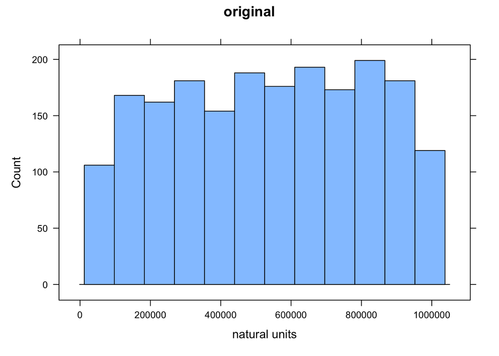

```r
histogram(house$Price,
          xlab="natural units",
          type="count",
          main="original")
```

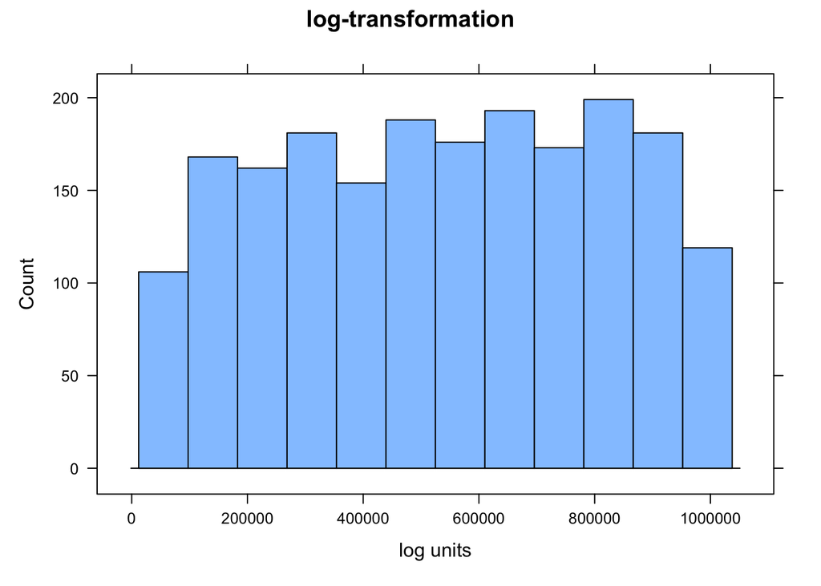

```r
histogram(house_trans$Price,
          xlab="log units",
          type="count",
          main="log-transformation")
```

**Interpretation:**

Since skewness is most likely lower, so there is not significant change even after the Box-Cox transformation. Hence we don’t need to transformed the features.

## Binning on `YearBuilt` variable

```r
house$YearBuiltBin <- cut(
                    house$YearBuilt,
                    breaks = c(1900, 1925,1950, 1975, 2000, 2025),
                    labels = c("1900–1925", "1926–1950", "1951-1975", "1976–2000", "2001–2025"),
                    include.lowest = TRUE
                  )
```

```r
table(house$YearBuiltBin)
```

```
##
## 1900–1925 1926–1950 1951-1975 1976–2000 2001–2025
##       431       394       391       404       380
```

```r
str(house)
```

```
## 'data.frame':    2000 obs. of  11 variables:
##  $ Area        : int  1360 4272 3592 966 4926 3944 3671 3419 630 2185 ...
##  $ Bedrooms    : Factor w/ 5 levels "1","2","3","4",..: 5 5 2 4 1 1 1 2 2 3 ...
##  $ Bathrooms   : Factor w/ 4 levels "1","2","3","4": 4 4 2 2 4 2 1 4 2 3 ...
##  $ Floors      : Factor w/ 3 levels "1","2","3": 3 3 3 2 2 1 2 1 1 1 ...
##  $ YearBuilt   : int  1970 1958 1938 1902 1975 1906 1948 1925 1932 2000 ...
##  $ Location    : Factor w/ 4 levels "Downtown","Rural",..: 1 1 1 3 1 4 2 3 2 1 ...
##  $ Condition   : Factor w/ 4 levels "Excellent","Fair",..: 1 1 3 2 2 4 4 3 4 4 ...
##  $ Garage      : Factor w/ 2 levels "No","Yes": 1 1 1 2 2 1 2 2 2 1 ...
##  $ Price       : int  149919 424998 266746 244020 636056 93262 448722 594893 652878 340375 ...
##  $ TotalRooms  : Factor w/ 8 levels "2","3","4","5",..: 8 8 3 5 4 2 1 5 3 5 ...
##  $ YearBuiltBin: Factor w/ 5 levels "1900–1925","1926–1950",..: 3 3 2 1 3 1 2 1 2 4 ...
```

```r
# remove `YearBuilt` variabel from dataset `house`
house <- house[,-5]
```

```r
str(house)
```

```
## 'data.frame':    2000 obs. of  10 variables:
##  $ Area        : int  1360 4272 3592 966 4926 3944 3671 3419 630 2185 ...
##  $ Bedrooms    : Factor w/ 5 levels "1","2","3","4",..: 5 5 2 4 1 1 1 2 2 3 ...
##  $ Bathrooms   : Factor w/ 4 levels "1","2","3","4": 4 4 2 2 4 2 1 4 2 3 ...
##  $ Floors      : Factor w/ 3 levels "1","2","3": 3 3 3 2 2 1 2 1 1 1 ...
##  $ Location    : Factor w/ 4 levels "Downtown","Rural",..: 1 1 1 3 1 4 2 3 2 1 ...
##  $ Condition   : Factor w/ 4 levels "Excellent","Fair",..: 1 1 3 2 2 4 4 3 4 4 ...
##  $ Garage      : Factor w/ 2 levels "No","Yes": 1 1 1 2 2 1 2 2 2 1 ...
##  $ Price       : int  149919 424998 266746 244020 636056 93262 448722 594893 652878 340375 ...
##  $ TotalRooms  : Factor w/ 8 levels "2","3","4","5",..: 8 8 3 5 4 2 1 5 3 5 ...
##  $ YearBuiltBin: Factor w/ 5 levels "1900–1925","1926–1950",..: 3 3 2 1 3 1 2 1 2 4 ...
```

## 2. Descriptive Statistics & Data Overview:-

```r
library(psych)
describe(house)
```

```
##               vars    n      mean        sd median   trimmed       mad   min
## Area             1 2000   2786.21   1295.15   2833   2792.45   1649.39   501
## Bedrooms*        2 2000      3.00      1.42      3      3.00      1.48     1
## Bathrooms*       3 2000      2.55      1.11      3      2.57      1.48     1
## Floors*          4 2000      1.99      0.81      2      1.99      1.48     1
## Location*        5 2000      2.45      1.14      2      2.43      1.48     1
## Condition*       6 2000      2.48      1.13      2      2.48      1.48     1
## Garage*          7 2000      1.48      0.50      1      1.48      0.00     1
## Price            8 2000 537676.85 276428.85 539254 540343.80 355701.69 50005
## TotalRooms*      9 2000      4.56      1.79      5      4.56      1.48     1
## YearBuiltBin*   10 2000      2.95      1.42      3      2.94      1.48     1
##                  max  range  skew kurtosis      se
## Area            4999   4498 -0.04    -1.20   28.96
## Bedrooms*          5      4 -0.02    -1.31    0.03
## Bathrooms*         4      3 -0.07    -1.34    0.02
## Floors*            3      2  0.01    -1.47    0.02
## Location*          4      3  0.06    -1.40    0.03
## Condition*         4      3  0.04    -1.38    0.03
## Garage*            2      1  0.08    -2.00    0.01
## Price         999656 949651 -0.06    -1.20 6181.14
## TotalRooms*        8      7 -0.01    -0.68    0.04
## YearBuiltBin*      5      4  0.03    -1.31    0.03
```

```r
summary(house)
```

```
##       Area      Bedrooms Bathrooms Floors      Location       Condition
##  Min.   : 501   1:418    1:461     1:661   Downtown:558   Excellent:511
##  1st Qu.:1653   2:368    2:494     2:691   Rural   :474   Fair     :521
##  Median :2833   3:406    3:524     3:648   Suburban:483   Good     :461
##  Mean   :2786   4:405    4:521             Urban   :485   Poor     :507
##  3rd Qu.:3888   5:403
##  Max.   :4999
##
##  Garage         Price          TotalRooms     YearBuiltBin
##  No :1038   Min.   : 50005   6      :408   1900–1925:431
##  Yes: 962   1st Qu.:300098   5      :383   1926–1950:394
##             Median :539254   4      :332   1951-1975:391
##             Mean   :537677   7      :298   1976–2000:404
##             3rd Qu.:780086   8      :213   2001–2025:380
##             Max.   :999656   3      :164
##                              (Other):202
```

## 2.1 Initial insights from Numerical data:

- **Area:** Properties also show a large range in size (501 to 4,999 sq ft) with mean sq.ft is 2786.21.
- **Price:** Property prices vary from $50,005.00 to ~ $1 million with average price is around $537,676.85. Its SD is higher($276428.85), so it indicates significantly dispersion.

## 2.2 Initial insights from categorical data:

**Location=>**

- Downtown: 558 Rural: 474 Suburban: 483 Urban: 485
- The distribution is relatively balanced within rural, suburban, & urban. But, downtown has more properties.

**Condition=>**

- Excellent:511 Fair:521 Good:461 Poor:507
- The distribution across condition grades are fairly unifrom except Good one.

**Garage=>**

- No:1038 Yes:962
- There is almost an even split between properties having Garage or not.

**YearBuilt=>**

- The distribution is almost evenly uniform at each 25 years period from 1900 to 2025.

## 3. EDA (Exploration Data Analysis) / Data Visualizations

## 3.1 Distribution of all numeric predictors including target `Price` w/o transformation

```r
cols_fac <- names(house)[sapply(house, is.factor)]
cols_num <- names(house)[sapply(house, is.numeric)]
cat('cols_fac=>',cols_fac,'\n')
```

```
## cols_fac=> Bedrooms Bathrooms Floors Location Condition Garage TotalRooms YearBuiltBin
```

```r
cat('cols_num=>',cols_num,'\n')
```

```
## cols_num=> Area Price
```

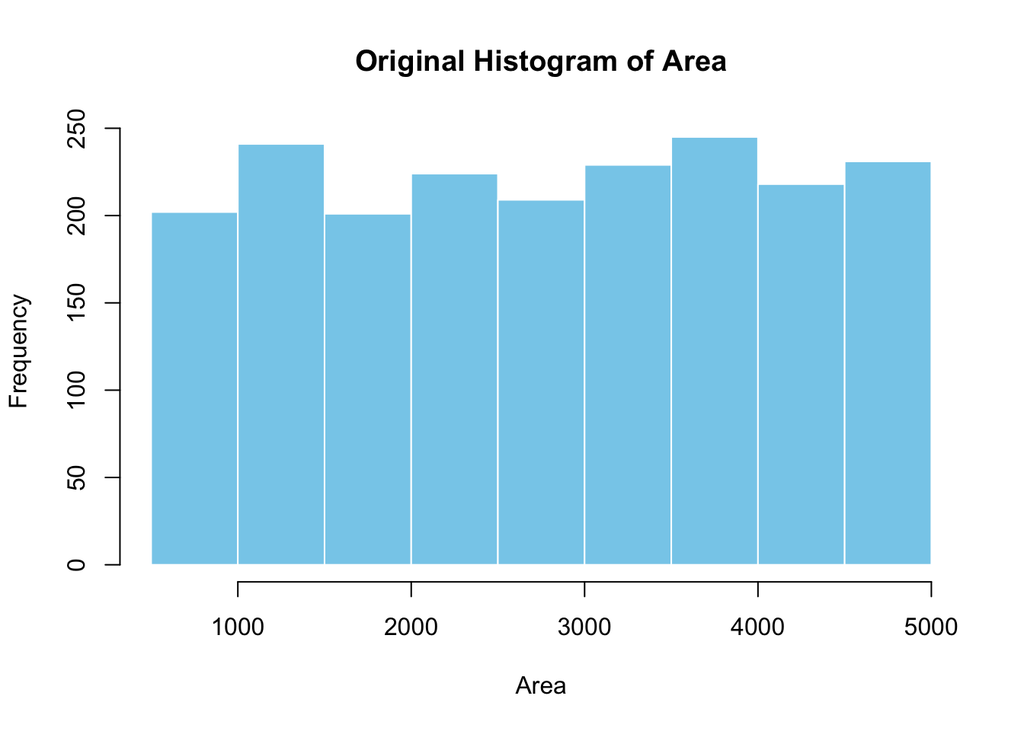

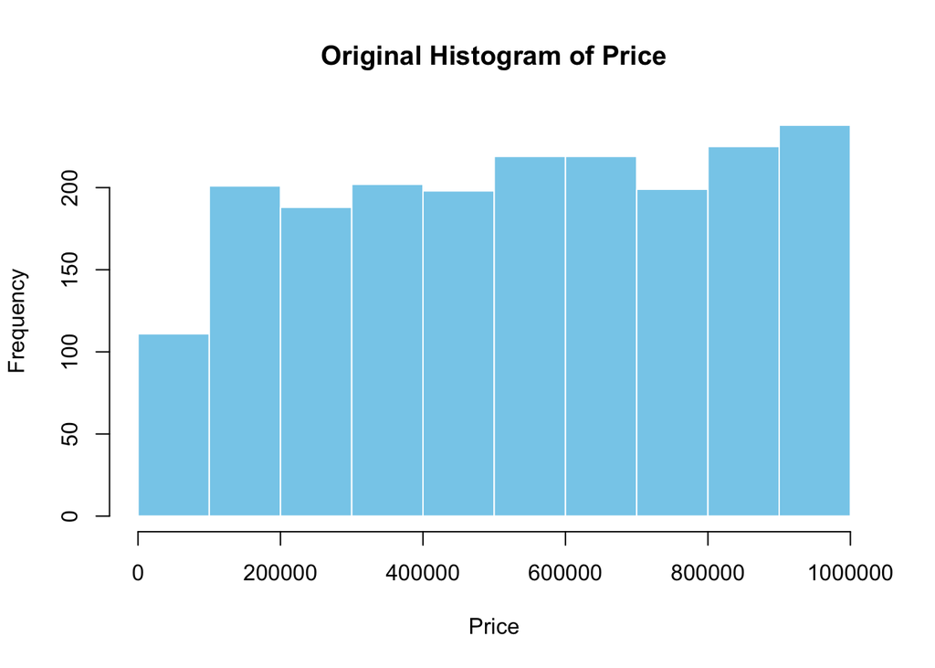

```r
options(scipen = 999)   # turn off scientific notation
# Histograms for all numerical predictors in house w/o transformation
for (col in cols_num) {
                        hist(house[[col]],
                        main = paste("Original Histogram of", col),
                        xlab = col,
                        col = "skyblue",
                        border = "white")
                                  }
```

```r
cols_num
```

```
## [1] "Area"  "Price"
```

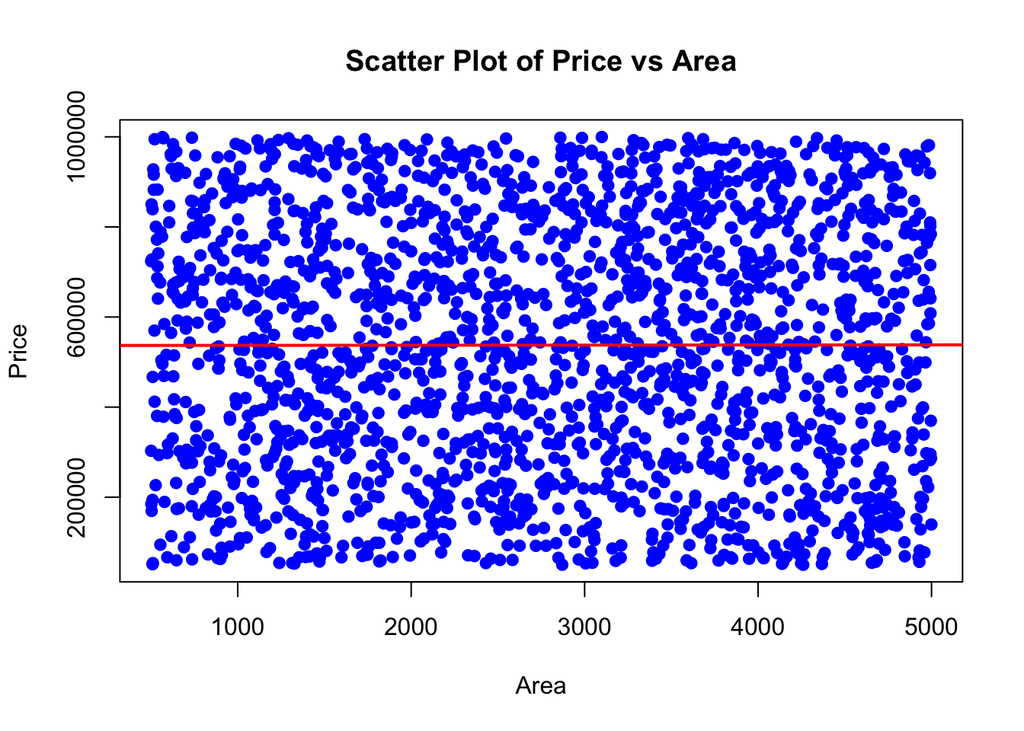

```r
plot(house$Area, house$Price,
     main = "Scatter Plot of Price vs Area",
     xlab = "Area",
     ylab = "Price",
     pch = 19,
     col = "blue")
abline(lm(Price ~ Area, data = house), col = "red", lwd = 2)
```

## 3.3 Box plot `Price` vs `categorical predictors` by using `For loop`

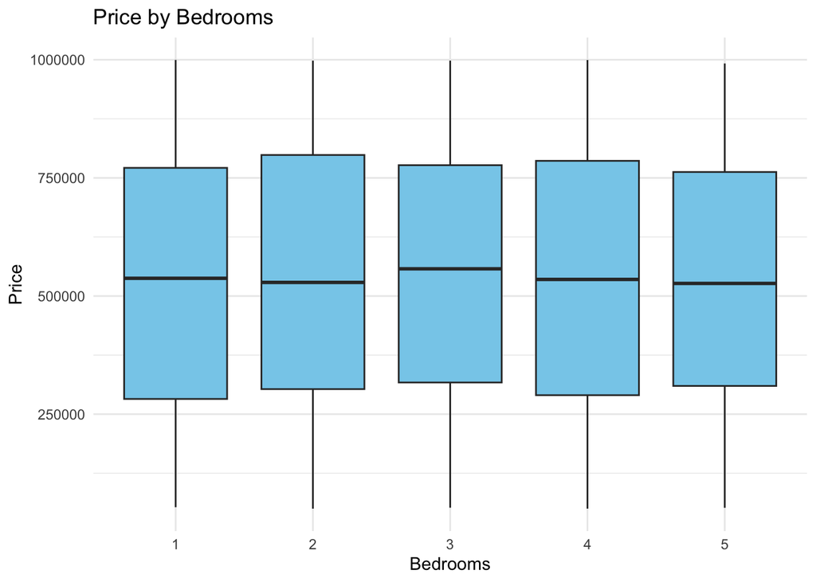

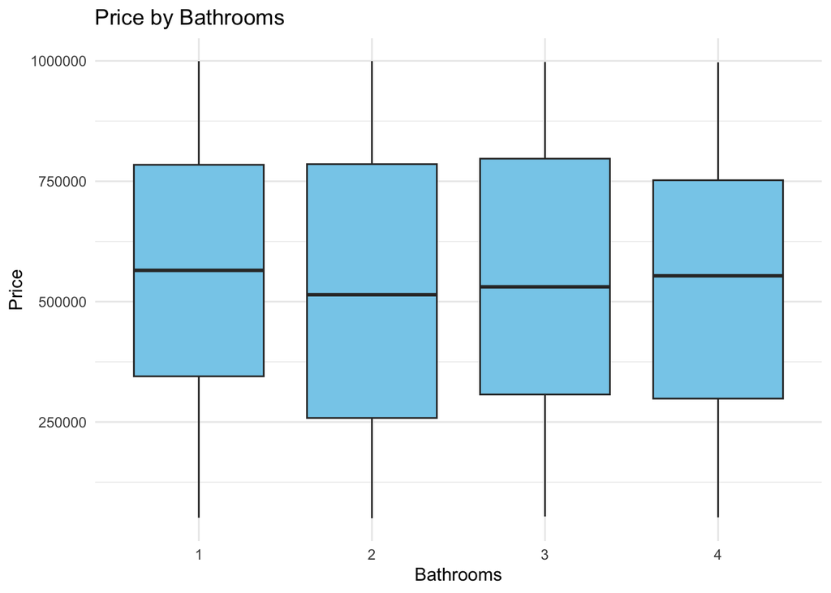

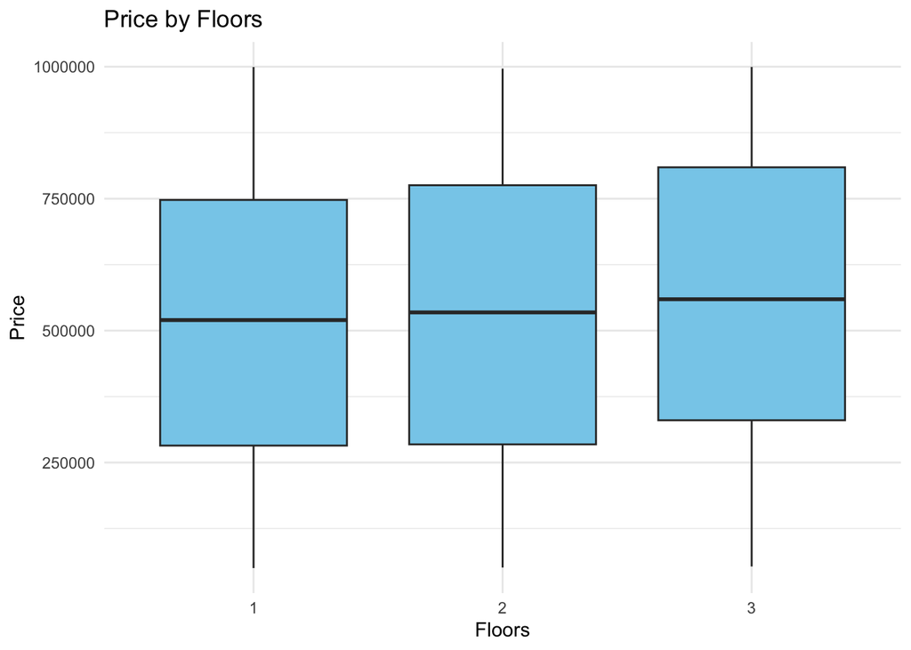

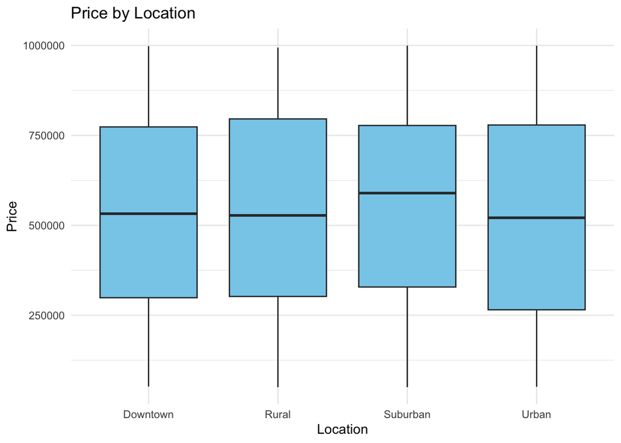

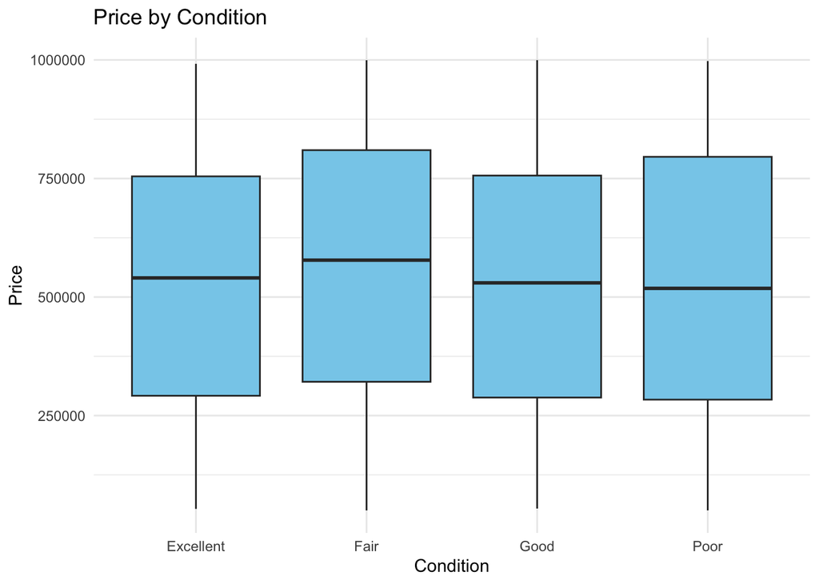

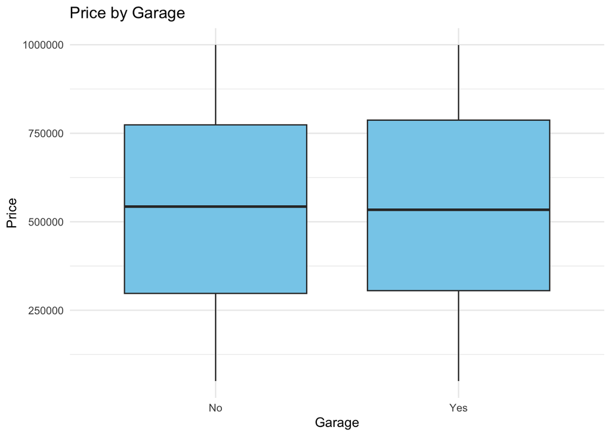

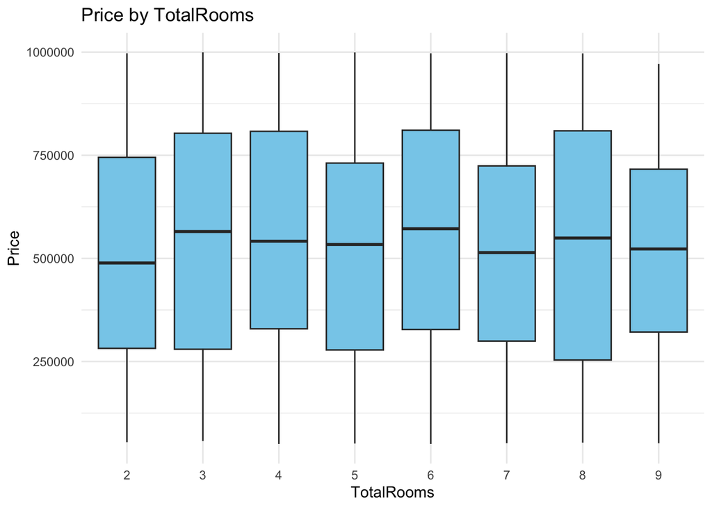

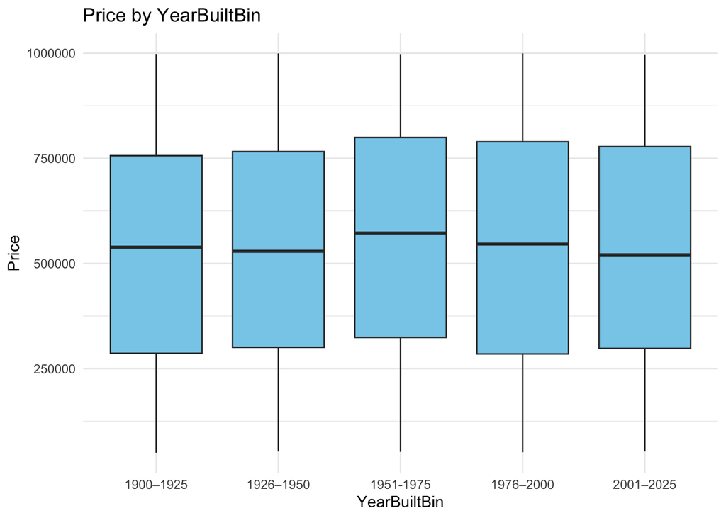

```r
for (col in cols_fac){
  boxplot <- ggplot(house, aes_string(x = col, y = 'Price')) +
             geom_boxplot(fill = "skyblue") +
             labs(title = paste("Price by", col))+
             theme_minimal()


  print(boxplot)

}
```

**Key Insight:** All predictors do not have outliers, so they are not making noises. All correlations are extremely weak (close to 0), with the strongest being `Floors-Price` at only 0.056. This suggests these features alone have very little linear relationship with house `Price` in your dataset.

**Potential Data Challenges**

## (1) What are the most significant factors influencing house prices?

```r
str(house)
```

```
## 'data.frame':    2000 obs. of  10 variables:
##  $ Area        : int  1360 4272 3592 966 4926 3944 3671 3419 630 2185 ...
##  $ Bedrooms    : Factor w/ 5 levels "1","2","3","4",..: 5 5 2 4 1 1 1 2 2 3 ...
##  $ Bathrooms   : Factor w/ 4 levels "1","2","3","4": 4 4 2 2 4 2 1 4 2 3 ...
##  $ Floors      : Factor w/ 3 levels "1","2","3": 3 3 3 2 2 1 2 1 1 1 ...
##  $ Location    : Factor w/ 4 levels "Downtown","Rural",..: 1 1 1 3 1 4 2 3 2 1 ...
##  $ Condition   : Factor w/ 4 levels "Excellent","Fair",..: 1 1 3 2 2 4 4 3 4 4 ...
##  $ Garage      : Factor w/ 2 levels "No","Yes": 1 1 1 2 2 1 2 2 2 1 ...
##  $ Price       : int  149919 424998 266746 244020 636056 93262 448722 594893 652878 340375 ...
##  $ TotalRooms  : Factor w/ 8 levels "2","3","4","5",..: 8 8 3 5 4 2 1 5 3 5 ...
##  $ YearBuiltBin: Factor w/ 5 levels "1900–1925","1926–1950",..: 3 3 2 1 3 1 2 1 2 4 ...
```

```r
model_lm_full <- lm(Price ~.,data=house)
```

```r
summary(model_lm_full)
```

```
##
## Call:
## lm(formula = Price ~ ., data = house)
##
## Residuals:
##     Min      1Q  Median      3Q     Max
## -579221 -232904    3678  242246  528965
##
## Coefficients: (1 not defined because of singularities)
##                           Estimate   Std. Error t value             Pr(>|t|)
## (Intercept)           472793.36150  37124.26405  12.735 < 0.0000000000000002
## Area                      -0.05555      4.78337  -0.012              0.99074
## Bedrooms2                449.64267  20901.89753   0.022              0.98284
## Bedrooms3               9521.23540  22538.94043   0.422              0.67275
## Bedrooms4               2862.41742  26045.30035   0.110              0.91250
## Bedrooms5              13054.20571  25869.56880   0.505              0.61388
## Bathrooms2            -50704.21484  18872.05462  -2.687              0.00728
## Bathrooms3            -20294.35805  20775.78460  -0.977              0.32877
## Bathrooms4             -8540.70893  21283.28336  -0.401              0.68825
## Floors2                15823.33094  15104.47876   1.048              0.29496
## Floors3                39531.27949  15270.43083   2.589              0.00970
## LocationRural           -377.56988  17304.59974  -0.022              0.98259
## LocationSuburban       19095.77509  17194.06083   1.111              0.26687
## LocationUrban         -23145.06650  17214.24447  -1.345              0.17893
## ConditionFair          30992.75068  17265.91893   1.795              0.07280
## ConditionGood          -2287.82310  17776.21032  -0.129              0.89761
## ConditionPoor            -38.24741  17387.81247  -0.002              0.99825
## GarageYes              -1800.19279  12428.92607  -0.145              0.88485
## TotalRooms3            67497.03910  35054.46940   1.925              0.05431
## TotalRooms4            69382.50334  30101.49436   2.305              0.02127
## TotalRooms5            34044.40319  27669.85350   1.230              0.21870
## TotalRooms6            72623.07585  27511.90739   2.640              0.00836
## TotalRooms7            28413.81455  30204.93028   0.941              0.34697
## TotalRooms8            39134.35385  33046.42402   1.184              0.23647
## TotalRooms9                     NA           NA      NA                   NA
## YearBuiltBin1926–1950    539.64766  19312.41610   0.028              0.97771
## YearBuiltBin1951-1975  34191.28916  19331.33937   1.769              0.07710
## YearBuiltBin1976–2000  16323.30669  19178.35841   0.851              0.39480
## YearBuiltBin2001–2025  -4489.50179  19510.78974  -0.230              0.81804
##
```

[output cut: 20 more lines]

```
## TotalRooms5
## TotalRooms6           **
## TotalRooms7
## TotalRooms8
## TotalRooms9
## YearBuiltBin1926–1950
## YearBuiltBin1951-1975 .
## YearBuiltBin1976–2000
## YearBuiltBin2001–2025
## ---
## Signif. codes:  0 '***' 0.001 '**' 0.01 '*' 0.05 '.' 0.1 ' ' 1
##
## Residual standard error: 275500 on 1972 degrees of freedom
## Multiple R-squared:  0.02002,    Adjusted R-squared:  0.0066
## F-statistic: 1.492 on 27 and 1972 DF,  p-value: 0.04985
```

Interpretation: At 5% significance level, the predictors `Bathrooms2` ,`Floor3`,`TotalRooms4`, `TotalRooms6` are the statisitically significant with the response variable `Price`. In other words, these are the influencing factors for the `house price`. Similarly, at 10% significance level, the predictors `ConditionFair`, `TotalRooms3`, `YearBuiltBin1951-1975` are the influencing factors for the `house price`. Since F-statistic p-value is 0.04985<0.05, Overall the model is statistically significant. That means, at least one predictors are affects the response.

## (2) Does the age of a house affect its market value?

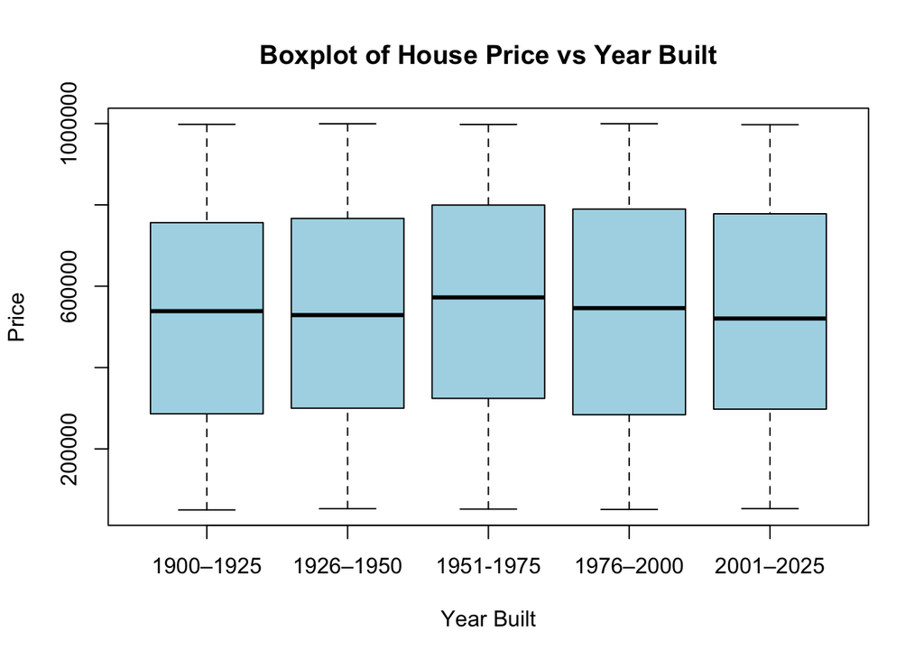

```r
options(scipen=999) # turn off scientific notation
boxplot(Price~YearBuiltBin, data=house,
        xlab='Year Built',
        ylab='Price',
        main='Boxplot of House Price vs Year Built',
        col='lightblue')
```

**Interpretation:**

The age of house is measured by `YearBuiltBin`.

From the summary of the linear multiple regression model `model_lm_full` , all the year built bin coefficients have high p-value >0.05. So there are no significant effect on the response variable `Price`in the linear model. However, the effect appear on the nonlinear model and may interact with other predictors.

**Conclusion:**

Although the `YearBuilt` does not significantly predict in this linear model, but

1. we should test interaction effects between predictors.
2. we may need a nonlinear model or log(Price) log transformation.

## (3) Do interactions between variables improve model accuracy?

```r
model_lm_interact <- lm(log(Price) ~ Area*Location + Condition*Location + Bedrooms*Bathrooms, data = house)
summary(model_lm_interact)
```

```
##
## Call:
## lm(formula = log(Price) ~ Area * Location + Condition * Location +
##     Bedrooms * Bathrooms, data = house)
##
## Residuals:
##     Min      1Q  Median      3Q     Max
## -2.2605 -0.3861  0.1994  0.5423  1.0151
##
## Coefficients:
##                                   Estimate  Std. Error t value
## (Intercept)                    12.82038386  0.10800158 118.706
## Area                            0.00002836  0.00002259   1.255
## LocationRural                   0.17005253  0.13092755   1.299
## LocationSuburban                0.24634442  0.12694275   1.941
## LocationUrban                   0.00750982  0.12802419   0.059
## ConditionFair                   0.13979830  0.08444866   1.655
## ConditionGood                   0.00437074  0.08451668   0.052
## ConditionPoor                  -0.04003236  0.08496488  -0.471
## Bedrooms2                       0.16262527  0.10982754   1.481
## Bedrooms3                       0.27480244  0.10221789   2.688
## Bedrooms4                       0.03653568  0.10496634   0.348
## Bedrooms5                       0.20238518  0.10159813   1.992
## Bathrooms2                     -0.01745860  0.10476888  -0.167
## Bathrooms3                      0.13372304  0.09676484   1.382
## Bathrooms4                      0.01145184  0.10047134   0.114
## Area:LocationRural             -0.00005173  0.00003483  -1.485
## Area:LocationSuburban          -0.00005596  0.00003413  -1.640
## Area:LocationUrban             -0.00003708  0.00003376  -1.098
## LocationRural:ConditionFair    -0.05286184  0.12379977  -0.427
## LocationSuburban:ConditionFair -0.12564757  0.12436007  -1.010
## LocationUrban:ConditionFair    -0.10038315  0.12499292  -0.803
## LocationRural:ConditionGood    -0.06889966  0.12880870  -0.535
## LocationSuburban:ConditionGood -0.00919344  0.12650574  -0.073
## LocationUrban:ConditionGood     0.08531879  0.12686491   0.673
## LocationRural:ConditionPoor     0.01005031  0.12528723   0.080
## LocationSuburban:ConditionPoor  0.00154238  0.12495508   0.012
## LocationUrban:ConditionPoor     0.11326589  0.12469705   0.908
## Bedrooms2:Bathrooms2           -0.17272313  0.14995825  -1.152
## Bedrooms3:Bathrooms2           -0.22979950  0.14614198  -1.572
```

[output cut: 41 more lines]

```
## Bedrooms5:Bathrooms2                        0.17092
## Bedrooms2:Bathrooms3                        0.10764
## Bedrooms3:Bathrooms3                        0.01695 *
## Bedrooms4:Bathrooms3                        0.59963
## Bedrooms5:Bathrooms3                        0.07980 .
## Bedrooms2:Bathrooms4                        0.71182
## Bedrooms3:Bathrooms4                        0.15289
## Bedrooms4:Bathrooms4                        0.72331
## Bedrooms5:Bathrooms4                        0.19980
## ---
## Signif. codes:  0 '***' 0.001 '**' 0.01 '*' 0.05 '.' 0.1 ' ' 1
##
## Residual standard error: 0.7122 on 1961 degrees of freedom
## Multiple R-squared:  0.02376,    Adjusted R-squared:  0.004845
## F-statistic: 1.256 on 38 and 1961 DF,  p-value: 0.1369
```

## Key summary statistics from output of the model `model_lm_interact` :

[output not shown]

**Conclusion:**

1. The extra interaction terms added complexity without improving predictive power of model. This means, interactions are only beneficial if there is evidence that one variable depends on another variable.
2. The interactions ( like Area**Location ,Condition**Location , Bedrooms*Bathrooms) do not meaningfully change the `Price`.
3. Most of the interaction coefficients have high p-value >0.05, so they are not statistically significant with the `Price`.

Hence due to all these reasons, i concluded that the model is overfitting without gaining accuracy.

## comparison between `Baseline linear multiple model` vs `interraction model`

[output not shown]

Conclusion:

From the comparison table, `model_lm_interact` model is not better as compare to `mode_lm_full` but it still does not explain the `Price` variation.

```r
# Convert factors to dummy variables
# `-1` drops intercept column
# house_dummies <- model.matrix(~., data = house)
house_dummies <- model.matrix(~.-1, data = house)
house_dummies <- as.data.frame(house_dummies)
```

```r
str(house_dummies)
```

```
## 'data.frame':    2000 obs. of  30 variables:
##  $ Area                 : num  1360 4272 3592 966 4926 ...
##  $ Bedrooms1            : num  0 0 0 0 1 1 1 0 0 0 ...
##  $ Bedrooms2            : num  0 0 1 0 0 0 0 1 1 0 ...
##  $ Bedrooms3            : num  0 0 0 0 0 0 0 0 0 1 ...
##  $ Bedrooms4            : num  0 0 0 1 0 0 0 0 0 0 ...
##  $ Bedrooms5            : num  1 1 0 0 0 0 0 0 0 0 ...
##  $ Bathrooms2           : num  0 0 1 1 0 1 0 0 1 0 ...
##  $ Bathrooms3           : num  0 0 0 0 0 0 0 0 0 1 ...
##  $ Bathrooms4           : num  1 1 0 0 1 0 0 1 0 0 ...
##  $ Floors2              : num  0 0 0 1 1 0 1 0 0 0 ...
##  $ Floors3              : num  1 1 1 0 0 0 0 0 0 0 ...
##  $ LocationRural        : num  0 0 0 0 0 0 1 0 1 0 ...
##  $ LocationSuburban     : num  0 0 0 1 0 0 0 1 0 0 ...
##  $ LocationUrban        : num  0 0 0 0 0 1 0 0 0 0 ...
```

[output cut: 16 more lines]

```r
head(house_dummies)
```

```
##   Area Bedrooms1 Bedrooms2 Bedrooms3 Bedrooms4 Bedrooms5 Bathrooms2 Bathrooms3
## 1 1360         0         0         0         0         1          0          0
## 2 4272         0         0         0         0         1          0          0
## 3 3592         0         1         0         0         0          1          0
## 4  966         0         0         0         1         0          1          0
## 5 4926         1         0         0         0         0          0          0
## 6 3944         1         0         0         0         0          1          0
##   Bathrooms4 Floors2 Floors3 LocationRural LocationSuburban LocationUrban
## 1          1       0       1             0                0             0
## 2          1       0       1             0                0             0
## 3          0       0       1             0                0             0
## 4          0       1       0             0                1             0
## 5          1       1       0             0                0             0
## 6          0       0       0             0                0             1
##   ConditionFair ConditionGood ConditionPoor GarageYes  Price TotalRooms3
```

[output cut: 27 more lines]

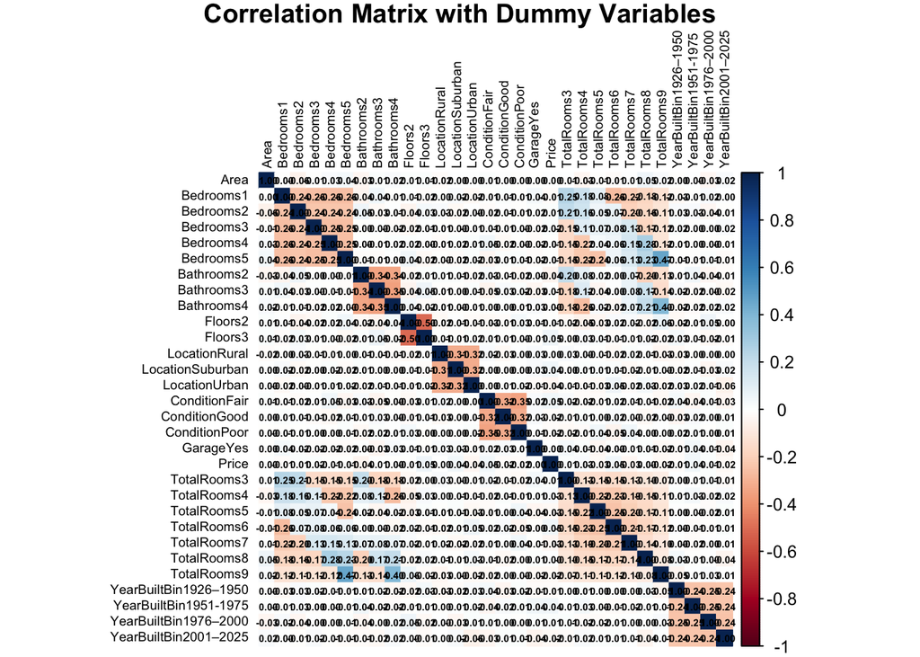

```r
library(corrplot)
cor_matrix <- cor(house_dummies, use = "pairwise.complete.obs")

# plot
corrplot(cor_matrix,
         method = "color",
         addCoef.col = "black",
         number.cex = 0.45,
         tl.cex = 0.6,
         tl.col = "black",
         title = "Correlation Matrix with Dummy Variables",
         mar = c(0,0,1,0))
```

```r
str(house_dummies)
```

```
## 'data.frame':    2000 obs. of  30 variables:
##  $ Area                 : num  1360 4272 3592 966 4926 ...
##  $ Bedrooms1            : num  0 0 0 0 1 1 1 0 0 0 ...
##  $ Bedrooms2            : num  0 0 1 0 0 0 0 1 1 0 ...
##  $ Bedrooms3            : num  0 0 0 0 0 0 0 0 0 1 ...
##  $ Bedrooms4            : num  0 0 0 1 0 0 0 0 0 0 ...
##  $ Bedrooms5            : num  1 1 0 0 0 0 0 0 0 0 ...
##  $ Bathrooms2           : num  0 0 1 1 0 1 0 0 1 0 ...
##  $ Bathrooms3           : num  0 0 0 0 0 0 0 0 0 1 ...
##  $ Bathrooms4           : num  1 1 0 0 1 0 0 1 0 0 ...
##  $ Floors2              : num  0 0 0 1 1 0 1 0 0 0 ...
##  $ Floors3              : num  1 1 1 0 0 0 0 0 0 0 ...
##  $ LocationRural        : num  0 0 0 0 0 0 1 0 1 0 ...
##  $ LocationSuburban     : num  0 0 0 1 0 0 0 1 0 0 ...
##  $ LocationUrban        : num  0 0 0 0 0 1 0 0 0 0 ...
```

[output cut: 16 more lines]

```r
model_lm_full <- lm(Price ~.,data=house_dummies)
```

```r
summary(model_lm_full)
```

```
##
## Call:
## lm(formula = Price ~ ., data = house_dummies)
##
## Residuals:
##     Min      1Q  Median      3Q     Max
## -579221 -232904    3678  242246  528965
##
## Coefficients: (2 not defined because of singularities)
##                             Estimate   Std. Error t value             Pr(>|t|)
## (Intercept)             485847.56721  34131.84399  14.234 < 0.0000000000000002
## Area                        -0.05555      4.78337  -0.012              0.99074
## Bedrooms1               -13054.20571  25869.56880  -0.505              0.61388
## Bedrooms2               -12604.56304  26155.84181  -0.482              0.62993
## Bedrooms3                -3532.97031  22685.62713  -0.156              0.87626
## Bedrooms4               -10191.78828  20583.47389  -0.495              0.62055
## Bedrooms5                         NA           NA      NA                   NA
## Bathrooms2              -50704.21484  18872.05462  -2.687              0.00728
## Bathrooms3              -20294.35805  20775.78460  -0.977              0.32877
## Bathrooms4               -8540.70893  21283.28336  -0.401              0.68825
## Floors2                  15823.33094  15104.47876   1.048              0.29496
## Floors3                  39531.27949  15270.43083   2.589              0.00970
## LocationRural             -377.56988  17304.59974  -0.022              0.98259
## LocationSuburban         19095.77509  17194.06083   1.111              0.26687
## LocationUrban           -23145.06650  17214.24447  -1.345              0.17893
## ConditionFair            30992.75068  17265.91893   1.795              0.07280
## ConditionGood            -2287.82310  17776.21032  -0.129              0.89761
## ConditionPoor              -38.24741  17387.81247  -0.002              0.99825
## GarageYes                -1800.19279  12428.92607  -0.145              0.88485
## TotalRooms3              67497.03910  35054.46940   1.925              0.05431
## TotalRooms4              69382.50334  30101.49436   2.305              0.02127
## TotalRooms5              34044.40319  27669.85350   1.230              0.21870
## TotalRooms6              72623.07585  27511.90739   2.640              0.00836
## TotalRooms7              28413.81455  30204.93028   0.941              0.34697
## TotalRooms8              39134.35385  33046.42402   1.184              0.23647
## TotalRooms9                       NA           NA      NA                   NA
## `YearBuiltBin1926–1950`    539.64766  19312.41610   0.028              0.97771
## `YearBuiltBin1951-1975`  34191.28916  19331.33937   1.769              0.07710
## `YearBuiltBin1976–2000`  16323.30669  19178.35841   0.851              0.39480
## `YearBuiltBin2001–2025`  -4489.50179  19510.78974  -0.230              0.81804
```

[output cut: 22 more lines]

```
## TotalRooms5
## TotalRooms6             **
## TotalRooms7
## TotalRooms8
## TotalRooms9
## `YearBuiltBin1926–1950`
## `YearBuiltBin1951-1975` .
## `YearBuiltBin1976–2000`
## `YearBuiltBin2001–2025`
## ---
## Signif. codes:  0 '***' 0.001 '**' 0.01 '*' 0.05 '.' 0.1 ' ' 1
##
## Residual standard error: 275500 on 1972 degrees of freedom
## Multiple R-squared:  0.02002,    Adjusted R-squared:  0.0066
## F-statistic: 1.492 on 27 and 1972 DF,  p-value: 0.04985
```

```r
library(car)
# vif(model_lm_full)
```